# Regresja i analiza wariancji - Sprawozdanie 1

Regresja liniowa

Lidia Furgał i Karolina Majdak

Politechnika Krakowska

# Analiza regresji liniowej prostej na zbiorze danych Carseats

Celem projektu jest dopasowanie modelu regresji liniowej prostej, który będzie przewidywał wartość zmiennej zależnej *Sales* na podstawie odpowiednio dobranej zmiennej objaśniającej ze zbioru danych *Carseats*. Dane te pochodzą z biblioteki **ISLR**. Proces doboru zmiennej objaśniającej zostanie przeprowadzony przy użyciu metod takich jak analiza współczynników korelacji oraz wykresy rozrzutu. Po dopasowaniu modelu ocenimy jego jakość przy pomocy współczynnika determinacji ($R^2$) oraz błędu standardowego. Na końcu dokonamy weryfikacji założeń modelu poprzez analizę reszt.

Zaimportujmy bibliotekę **ISLR**, która zawiera dane dotyczące zbioru danych *Carseats*.

```r
carseats <- tibble::as.tibble(ISLR::Carseats)
head(carseats)
```

| Sales | CompPrice | Income | Advertising | Population | Price | ShelveLoc | Age | Education | Urban | US |
| --- | --- | --- | --- | --- | --- | --- | --- | --- | --- | --- |
| 9.50 | 138 | 73 | 11 | 276 | 120 | Bad | 42 | 17 | Yes | Yes |
| 11.22 | 111 | 48 | 16 | 260 | 83 | Good | 65 | 10 | Yes | Yes |
| 10.06 | 113 | 35 | 10 | 269 | 80 | Medium | 59 | 12 | Yes | Yes |
| 7.40 | 117 | 100 | 4 | 466 | 97 | Medium | 55 | 14 | Yes | Yes |
| 4.15 | 141 | 64 | 3 | 340 | 128 | Bad | 38 | 13 | Yes | No |
| 10.81 | 124 | 113 | 13 | 501 | 72 | Bad | 78 | 16 | No | Yes |

Na podstawie współczynnika korelacji Pearsona oraz macierzy korelacji zidentyfikujmy odpowiednią zmienną objaśniającą, która posłuży do przewidywania wartości zmiennej *Sales* w modelu regresji liniowej prostej.

```r
cor.test(carseats$Sales,carseats$CompPrice)
```

```
##
##  Pearson's product-moment correlation
##
## data:  carseats$Sales and carseats$CompPrice
## t = 1.281, df = 398, p-value = 0.2009
## alternative hypothesis: true correlation is not equal to 0
## 95 percent confidence interval:
##  -0.03418779  0.16111814
## sample estimates:
##        cor
## 0.06407873
```

```r
cor.test(carseats$Sales,carseats$Income)
```

```
##
##  Pearson's product-moment correlation
##
## data:  carseats$Sales and carseats$Income
## t = 3.067, df = 398, p-value = 0.00231
## alternative hypothesis: true correlation is not equal to 0
## 95 percent confidence interval:
##  0.05471445 0.24633258
## sample estimates:
##      cor
## 0.151951
```

```r
cor.test(carseats$Sales,carseats$Advertising)
```

```
##
##  Pearson's product-moment correlation
##
## data:  carseats$Sales and carseats$Advertising
## t = 5.5832, df = 398, p-value = 4.378e-08
## alternative hypothesis: true correlation is not equal to 0
## 95 percent confidence interval:
##  0.1761088 0.3580956
## sample estimates:
##       cor
## 0.2695068
```

```r
cor.test(carseats$Sales,carseats$Population)
```

```
##
##  Pearson's product-moment correlation
##
## data:  carseats$Sales and carseats$Population
## t = 1.0082, df = 398, p-value = 0.314
## alternative hypothesis: true correlation is not equal to 0
## 95 percent confidence interval:
##  -0.04781737  0.14779132
## sample estimates:
##        cor
## 0.05047098
```

```r
cor.test(carseats$Sales,carseats$Price)
```

```
##
##  Pearson's product-moment correlation
##
## data:  carseats$Sales and carseats$Price
## t = -9.912, df = 398, p-value < 2.2e-16
## alternative hypothesis: true correlation is not equal to 0
## 95 percent confidence interval:
##  -0.5203026 -0.3627240
## sample estimates:
##        cor
## -0.4449507
```

```r
cor.test(carseats$Sales,carseats$Age)
```

```
##
##  Pearson's product-moment correlation
##
## data:  carseats$Sales and carseats$Age
## t = -4.7542, df = 398, p-value = 2.789e-06
## alternative hypothesis: true correlation is not equal to 0
## 95 percent confidence interval:
##  -0.3225359 -0.1368749
## sample estimates:
##        cor
## -0.2318154
```

```r
cor.test(carseats$Sales,carseats$Education)
```

```
##
##  Pearson's product-moment correlation
##
## data:  carseats$Sales and carseats$Education
## t = -1.0379, df = 398, p-value = 0.2999
## alternative hypothesis: true correlation is not equal to 0
## 95 percent confidence interval:
##  -0.14924665  0.04633251
## sample estimates:
##         cor
## -0.05195524
```

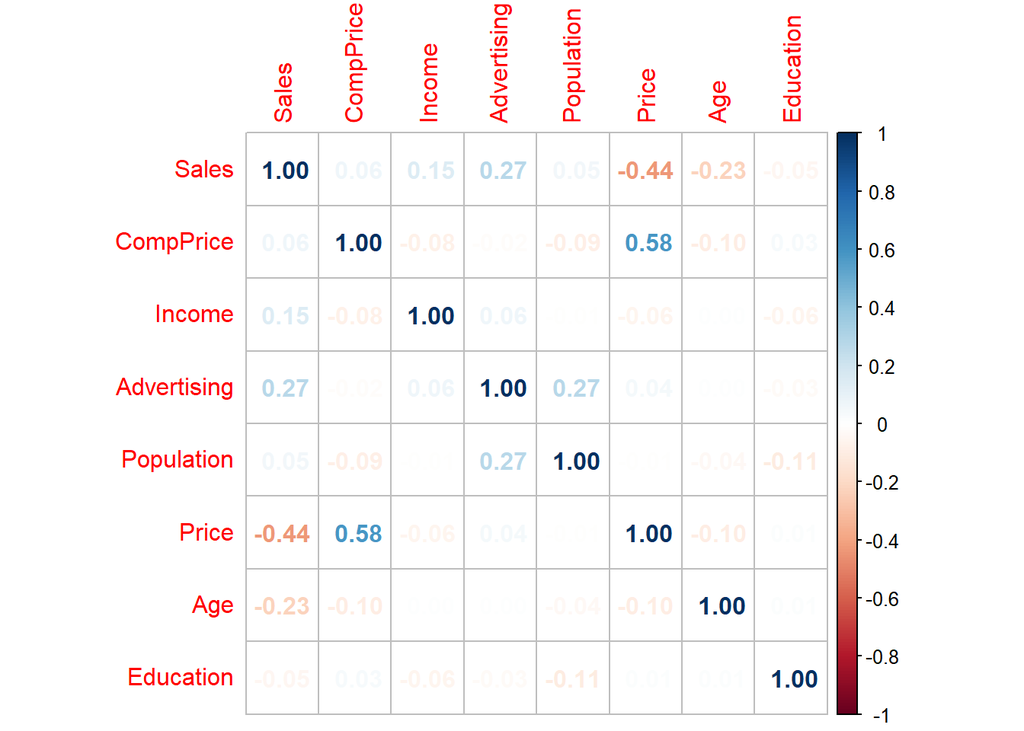

```r
cars_sample_matrix <- round(cor(carseats[,c(1,2,3,4,5,6,8,9)]),2)
corrplot(cars_sample_matrix, method = 'number')
```

Na podstawie obliczonych wartości współczynnika korelacji oraz analizy macierzy korelacji ustalono, że zmienną o najsilniejszej zależności ze zmienną *Sales* jest zmienna *Price*, której współczynnik korelacji wynosi $\rho$ = -0,44.

Stwórzmy wykres ilustrujący zależność między zmienną *Sales* a zmienną *Price*, przedstawiający sprzedaż fotelików samochodowych w kontekście ich ceny.

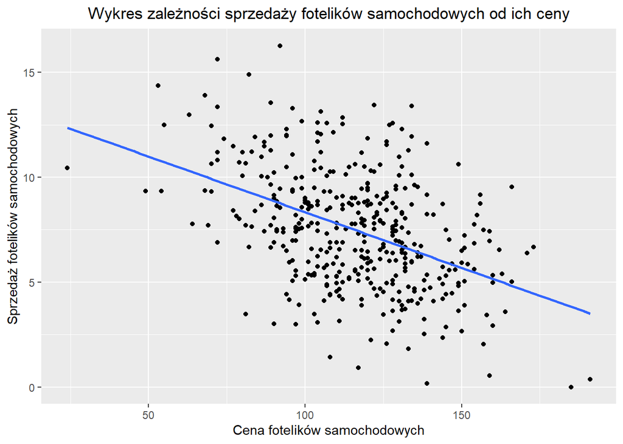

```r
ggplot(carseats, aes(x=Price, y=Sales)) + geom_point() +
labs(title="Wykres zależności sprzedaży fotelików samochodowych od ich ceny", x='Cena fotelików samochodowych', y = "Sprzedaż fotelików samochodowych") + geom_smooth(method='lm' ,formula=y~x, se=FALSE) + theme(plot.title = element_text(hjust = 0.5))
```

Zbudujmy model regresji liniowej, w którym sprzedaż fotelików samochodowych jest objaśniana ich ceną.

```r
linear_regression <- lm(carseats$Sales ~ carseats$Price)
linear_regression
```

```
##
## Call:
## lm(formula = carseats$Sales ~ carseats$Price)
##
## Coefficients:
##    (Intercept)  carseats$Price
##       13.64192        -0.05307
```

Skorzystajmy z funkcji *summary*, aby ocenić, czy analizowany model regresji jest zasadny.

```r
linear_regression_summary<-summary(linear_regression)
linear_regression_summary
```

```
##
## Call:
## lm(formula = carseats$Sales ~ carseats$Price)
##
## Residuals:
##     Min      1Q  Median      3Q     Max
## -6.5224 -1.8442 -0.1459  1.6503  7.5108
##
## Coefficients:
##                 Estimate Std. Error t value Pr(>|t|)
## (Intercept)    13.641915   0.632812  21.558   <2e-16 ***
## carseats$Price -0.053073   0.005354  -9.912   <2e-16 ***
## ---
## Signif. codes:  0 '***' 0.001 '**' 0.01 '*' 0.05 '.' 0.1 ' ' 1
##
## Residual standard error: 2.532 on 398 degrees of freedom
## Multiple R-squared:  0.198,  Adjusted R-squared:  0.196
## F-statistic: 98.25 on 1 and 398 DF,  p-value: < 2.2e-16
```

Na podstawie wartości $R^2$ wynoszącej $0,196$ możemy wnioskować, że cena fotelików samochodowych ma słaby wpływ na ich sprzedaż.

Następnie przeanalizujmy założenia dotyczące reszt modelu, oznaczanych jako $\epsilon_i$. Na początek sprawdźmy ich normalność, wykorzystując metody graficzne, takie jak histogram i wykres kwantyl-kwantyl, a także przeprowadzając test Shapiro-Wilka. Przyjmujemy, że hipoteza zerowa dotyczy normalności reszt, a poziom istotności wynosi $0,05$.

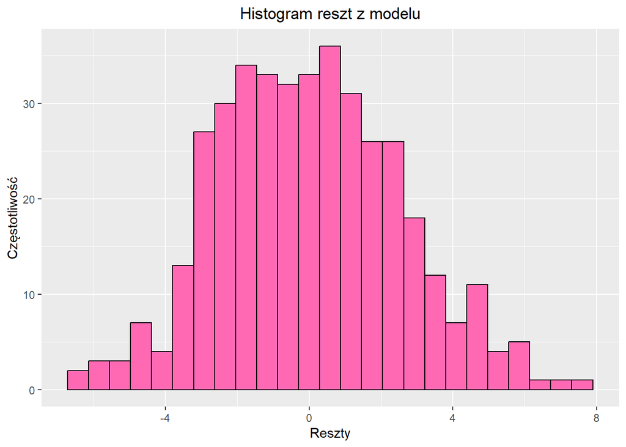

```r
ggplot(linear_regression, aes(x = .resid)) + geom_histogram(bins = 25, fill = "#FF69B4", color = 'black') + labs(title = 'Histogram reszt z modelu', x = 'Reszty', y = 'Częstotliwość') + theme(plot.title = element_text(hjust = 0.5))
```

Histogram reszt jest stosunkowo symetryczny i w znacznym stopniu przypomina histogram rozkładu normalnego.

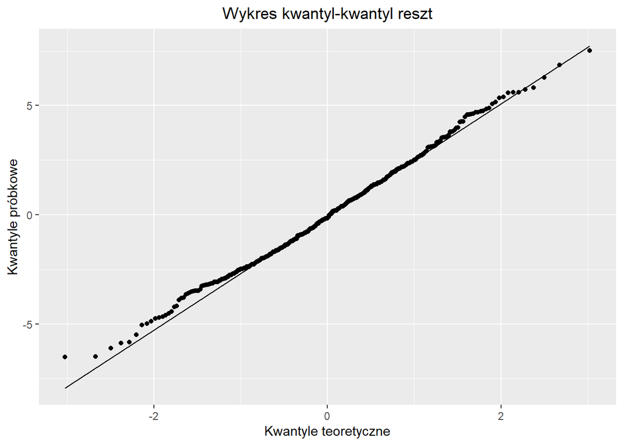

```r
ggplot(linear_regression, aes(sample=.resid)) + geom_qq() + geom_qq_line() + labs(title='Wykres kwantyl-kwantyl reszt', x='Kwantyle teoretyczne', y='Kwantyle próbkowe') + theme(plot.title = element_text(hjust = 0.5))
```

Na podstawie wykresu kwantyl-kwantyl można stwierdzić, że nie występują istotne odstępstwa od rozkładu normalnego.

```r
shapiro.test(linear_regression$residuals)
```

```
##
##  Shapiro-Wilk normality test
##
## data:  linear_regression$residuals
## W = 0.9953, p-value = 0.2699
```

Na podstawie uzyskanej wartości **p-value** ($p=0,2699$), która jest większa od ustalonego poziomu istotności, nie mamy podstaw do odrzucenia hipotezy zerowej. W związku z tym możemy stwierdzić, że reszty modelu mają rozkład normalny.

Zastosujmy test t-Studenta, aby sprawdzić, czy założenie dotyczące zerowej średniej reszt jest spełnione. Hipoteza zerowa $H_0: \mu = 0$ oznacza, że średnia reszt jest równa zeru, podczas gdy hipoteza alternatywna $H_1: \mu \neq 0$ sugeruje, że średnia reszt różni się od zera.

```r
t.test(linear_regression$residuals)
```

```
##
##  One Sample t-test
##
## data:  linear_regression$residuals
## t = 1.7844e-15, df = 399, p-value = 1
## alternative hypothesis: true mean is not equal to 0
## 95 percent confidence interval:
##  -0.2486063  0.2486063
## sample estimates:
##    mean of x
## 2.256517e-16
```

Ponieważ wartość $p > 0,05$, przyjmujemy hipotezę zerową. Dodatkowo, analizując wykres „Residuals vs Fitted”, możemy potwierdzić, że średnia reszt jest bliska zeru oraz wykazać niezależność reszt, co stanowi kolejne założenie modelu.

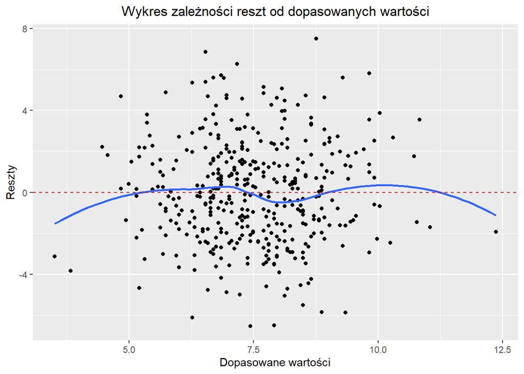

```r
ggplot(linear_regression, aes(.fitted, .resid)) + geom_point() + stat_smooth(method='loess', formula=y~x, se=FALSE) +
geom_hline(yintercept=0, linetype='dashed', color='red') + labs(title='Wykres zależności reszt od dopasowanych wartości', x='Dopasowane wartości',y='Reszty')+ theme(plot.title = element_text(hjust = 0.5))
```

Aby ocenić, czy reszty wykazują niezależność, przeprowadźmy test Durbina-Watsona, zakładając brak struktury autoregresyjnej w modelu. Na początek załadujmy niezbędną bibliotekę *lmtest*.

Następnie przeprowadźmy test Durbina-Watsona, aby ocenić niezależność reszt.

```r
lmtest::dwtest(linear_regression)
```

```
##
##  Durbin-Watson test
##
## data:  linear_regression
## DW = 1.8922, p-value = 0.1403
## alternative hypothesis: true autocorrelation is greater than 0
```

Ponieważ wartość $p > 0,05$, przyjmujemy hipotezę zerową, która zakłada niezależność reszt.

Aby ocenić wariancję reszt, musimy sprawdzić, czy dane są losowo rozproszone wokół stałej wartości $\sigma$. W tym celu wykorzystamy metody graficzne oraz test Breuscha-Pagana.

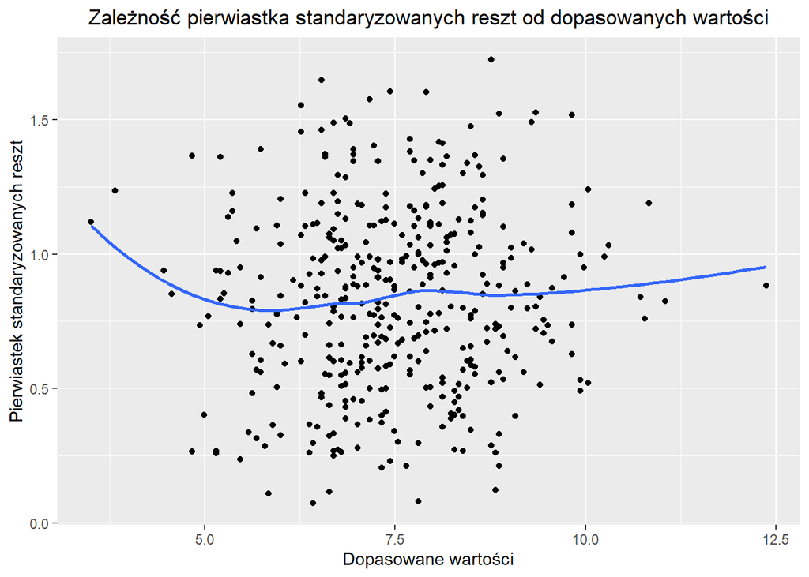

```r
ggplot(linear_regression, aes(.fitted, sqrt(abs(.stdresid)))) + geom_point() + stat_smooth(method='loess', formula=y~x, se=FALSE) + labs(title='Zależność pierwiastka standaryzowanych reszt od dopasowanych wartości', x='Dopasowane wartości', y='Pierwiastek standaryzowanych reszt')+ theme(plot.title = element_text(hjust = 0.5))
```

```r
lmtest::bptest(linear_regression)
```

```
##
##  studentized Breusch-Pagan test
##
## data:  linear_regression
## BP = 0.21941, df = 1, p-value = 0.6395
```

Na podstawie wizualizacji oraz wartości **p-value** uzyskanej w teście Breuscha-Pagana ($p = 0,6395$) możemy stwierdzić, że reszty wykazują homoskedastyczność. W związku z tym rozpatrywany model spełnia wszystkie założenia modelu regresji liniowej prostej.

# Analiza regresji liniowej wielorakiej na zbiorze danych Carseats

Dopasujmy model regresji liniowej wielorakiej, który przewiduje wartość zmiennej *Sales*. W pierwszej kolejności zidentyfikujemy zmienne objaśniające na podstawie analizy współczynnika korelacji. W tym celu wykonamy macierz korelacji, co pozwoli nam określić zmienne, które wykazują najsilniejszą zależność ze zmienną *Sales*.

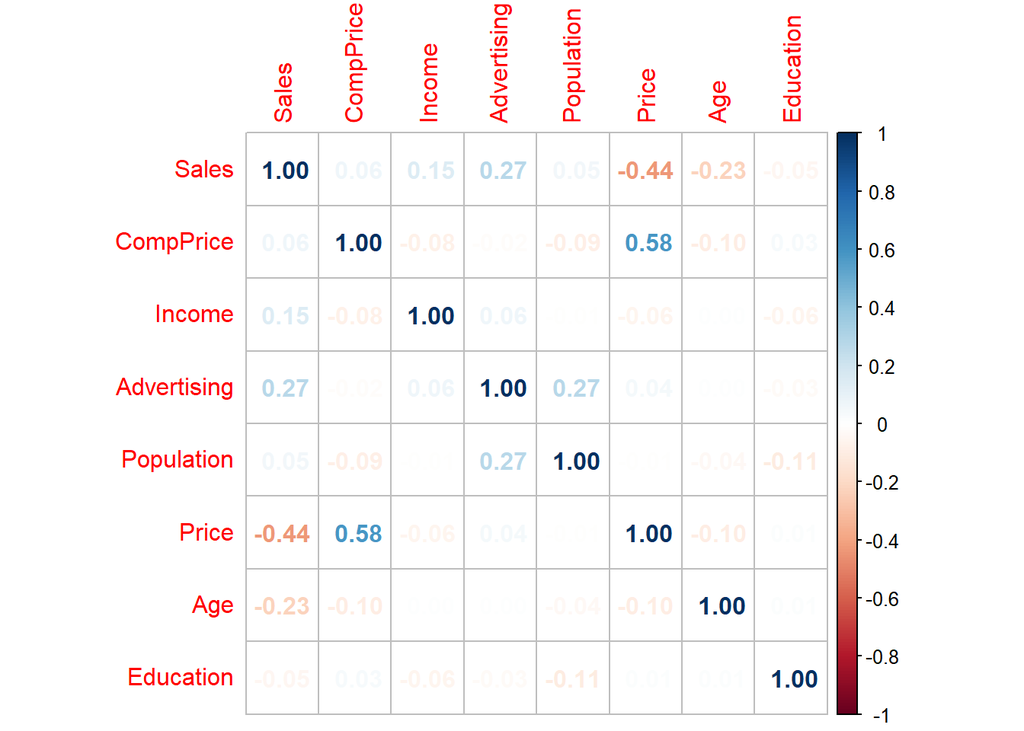

```r
cars_sample_matrix <- round(cor(carseats[,c(1,2,3,4,5,6,8,9)]),2)
corrplot(cars_sample_matrix, method = 'number')
```

Stwórzmy model regresji liniowej wielorakiej, w którym zmienne objaśniające to *Price*, *Age* oraz *Advertising*.

```r
multiple_regression <- lm(carseats$Sales ~ carseats$Price+carseats$Age+carseats$Advertising)
```

```r
multiple_regression
```

```
##
## Call:
## lm(formula = carseats$Sales ~ carseats$Price + carseats$Age +
##     carseats$Advertising)
##
## Coefficients:
##          (Intercept)        carseats$Price          carseats$Age
##             16.00347              -0.05803              -0.04885
## carseats$Advertising
##              0.12311
```

```r
multiple_regression_summary<-summary(multiple_regression)
```

```r
multiple_regression_summary
```

```
##
## Call:
## lm(formula = carseats$Sales ~ carseats$Price + carseats$Age +
##     carseats$Advertising)
##
## Residuals:
##     Min      1Q  Median      3Q     Max
## -6.6247 -1.5288  0.0148  1.5220  6.2925
##
## Coefficients:
##                       Estimate Std. Error t value Pr(>|t|)
## (Intercept)          16.003472   0.718754  22.266  < 2e-16 ***
## carseats$Price       -0.058028   0.004827 -12.022  < 2e-16 ***
## carseats$Age         -0.048846   0.007047  -6.931 1.70e-11 ***
## carseats$Advertising  0.123106   0.017095   7.201 3.02e-12 ***
## ---
## Signif. codes:  0 '***' 0.001 '**' 0.01 '*' 0.05 '.' 0.1 ' ' 1
##
## Residual standard error: 2.269 on 396 degrees of freedom
## Multiple R-squared:  0.3595, Adjusted R-squared:  0.3547
## F-statistic:  74.1 on 3 and 396 DF,  p-value: < 2.2e-16
```

W modelu regresji liniowej wielorakiej wartość $R^2$ wynosi $0,35$, co jest wyższe od wartości uzyskanej w modelu regresji liniowej prostej ($R^2 = 0,20$), co sugeruje lepszą jakość modelu wielorakiego. Należy jednak zauważyć, że to stwierdzenie może być mylące, ponieważ dodawanie kolejnych zmiennych objaśniających zawsze zwiększa wartość $R^2$.

Sprawdźmy kolejno założenia modelu regresji liniowej wielorakiej, które są takie same jak założenia dla modelu regresji liniowej prostej. Początkowo przeanalizujmy normalność reszt.

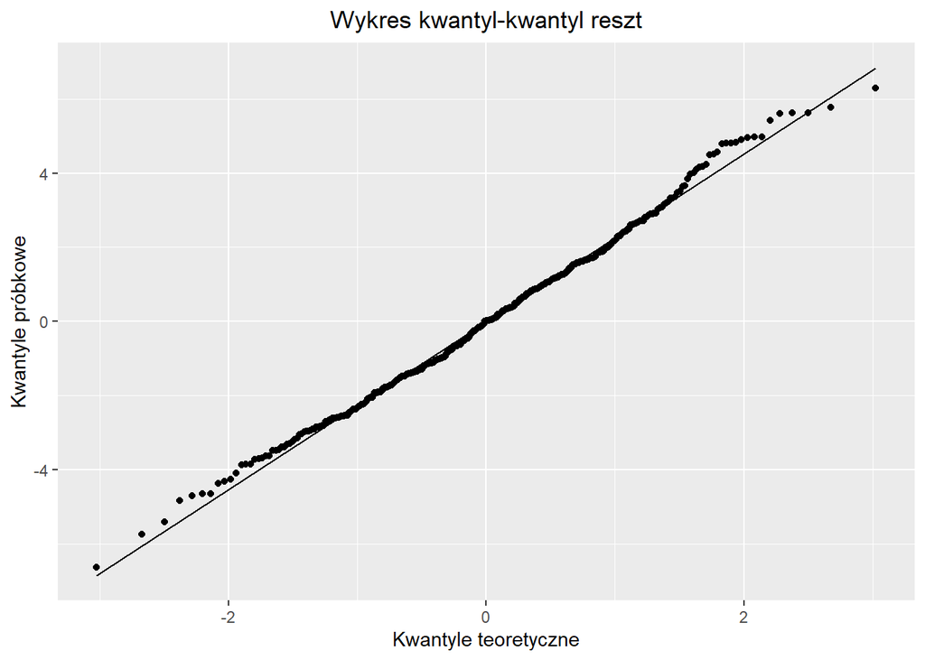

```r
ggplot(multiple_regression, aes(sample=.resid)) + geom_qq() + geom_qq_line() + labs(title='Wykres kwantyl-kwantyl reszt', x='Kwantyle teoretyczne', y='Kwantyle próbkowe')+ theme(plot.title = element_text(hjust = 0.5))
```

```r
shapiro.test(multiple_regression$residuals)
```

```
##
##  Shapiro-Wilk normality test
##
## data:  multiple_regression$residuals
## W = 0.99509, p-value = 0.2367
```

Na podstawie wykresu kwantyl-kwantyl oraz testu Shapiro-Wilka ($p = 0,2367$) możemy stwierdzić, że założenie dotyczące normalności reszt modelu jest spełnione.

```r
t.test(multiple_regression$residuals)
```

```
##
##  One Sample t-test
##
## data:  multiple_regression$residuals
## t = -8.0537e-16, df = 399, p-value = 1
## alternative hypothesis: true mean is not equal to 0
## 95 percent confidence interval:
##  -0.2221584  0.2221584
## sample estimates:
##     mean of x
## -9.101064e-17
```

W związku z tym, że wartość **p-value** jest większa niż $0,05$, przyjmujemy hipotezę zerową, co sugeruje, że średnia reszt jest bliska zeru. Dodatkowo, analizując wykres „Residuals vs Fitted”, możemy potwierdzić, że reszty są rozproszone losowo wokół zera. Taki układ punktów wskazuje również na niezależność reszt, co stanowi jedno z kluczowych założeń modelu regresji liniowej wielorakiej.

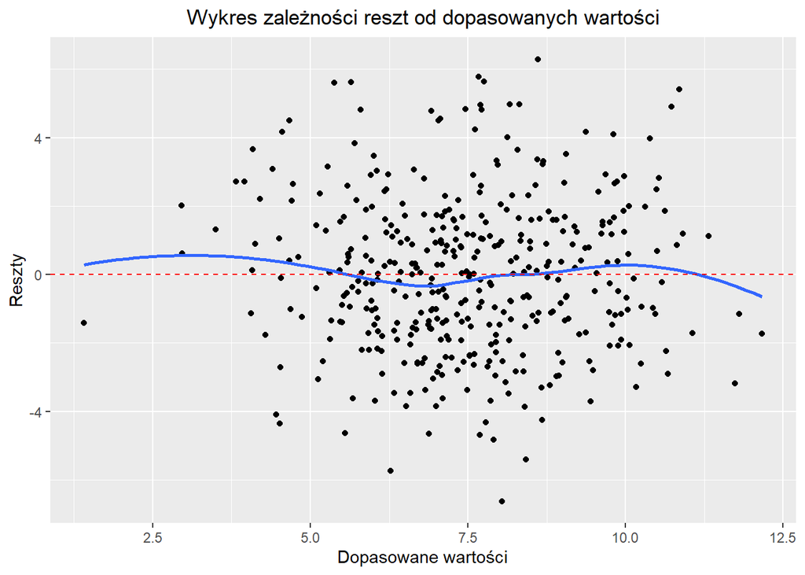

```r
ggplot(multiple_regression, aes(.fitted, .resid)) + geom_point() + stat_smooth(method='loess', formula=y~x, se=FALSE) +
geom_hline(yintercept=0, linetype='dashed', color='red') + labs(title='Wykres zależności reszt od dopasowanych wartości', x='Dopasowane wartości', y='Reszty')+ theme(plot.title = element_text(hjust = 0.5))
```

Aby sprawdzić niezależność reszt, przeprowadzimy test Durbina-Watsona.

```r
lmtest::dwtest(multiple_regression)
```

```
##
##  Durbin-Watson test
##
## data:  multiple_regression
## DW = 1.9544, p-value = 0.3238
## alternative hypothesis: true autocorrelation is greater than 0
```

Jako że wartość **p-value** wynosi $0,3238$, co jest większe od przyjętego poziomu istotności, przyjmujemy hipotezę zerową, która zakłada niezależność reszt.

Aby ocenić wariancję reszt w modelu regresji liniowej wielorakiej, zastosujemy metody analizy graficznej oraz test Breuscha-Pagana, analogicznie do wcześniejszej analizy w modelu regresji liniowej prostej.

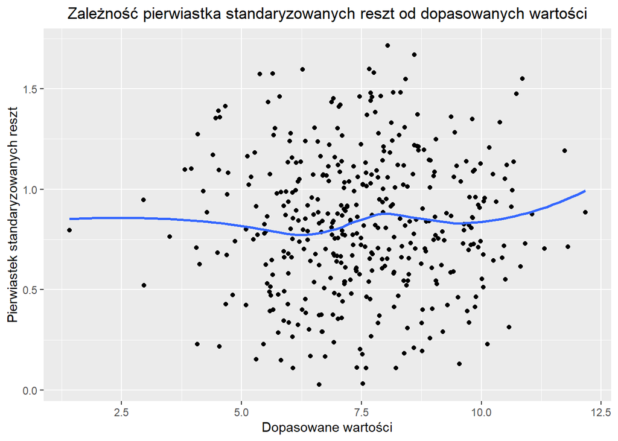

```r
ggplot(multiple_regression, aes(.fitted, sqrt(abs(.stdresid)))) + geom_point() + stat_smooth(method='loess', formula=y~x, se=FALSE) + labs(title='Zależność pierwiastka standaryzowanych reszt od dopasowanych wartości', x='Dopasowane wartości', y='Pierwiastek standaryzowanych reszt')+ theme(plot.title = element_text(hjust = 0.5))
```

```r
lmtest::bptest(multiple_regression)
```

```
##
##  studentized Breusch-Pagan test
##
## data:  multiple_regression
## BP = 0.25617, df = 3, p-value = 0.968
```